# Explore EPIC results

Stephanie J. Spielman

2025-01-21

The goal of this notebook is to explore the `EPIC` results obtained with both of its references `TRef` or `BRef`. These two distinct references estimate the proportions of the following cell types (note they use these strings, not ontologies), where I have bolded the cell types they share:

- The `TRef` reference (7 + other):
  - **`Bcells`**
  - `CAFs` (cancer-associated fibroblasts)
  - **`CD4_Tcells`**
  - **`CD8_Tcells`**
  - `Endothelial`
  - `Macrophages`
  - **`NKcells`**
  - `otherCells`
- The `BRef` reference (6 + other):
  - **`Bcells`**
  - **`CD4_Tcells`**
  - **`CD8_Tcells`**
  - `Monocytes`
  - `Neutrophils`
  - **`NKcells`**
  - `otherCells`

## Setup

```r
renv::load()

library(ggplot2)
theme_set(theme_bw())
```

### Paths

```r
results_dir <- here::here("analysis", "bulk-deconvolution", "results")

epic_files <- list.files(
  path = results_dir,
  full.names = TRUE,
  pattern = "*-epic.tsv$"
)
project_ids <- stringr::str_split_i(basename(epic_files), pattern = "-", i = 1)
epic_files <- setNames(epic_files, project_ids)
```

### Prepare input data

First, we’ll read in the `EPIC` results and have an initial look at the cell type distributions obtained from each reference in order to select a reference for each project to proceed with.

```r
# Read in epic result TSVs and combine into single data frame
epic_raw_df <- epic_files |>
  purrr::map(\(file) readr::read_tsv(file, show_col_types = FALSE)) |>
  purrr::list_rbind(names_to = "project_id")
```

## Compare references

Considering all categories of cells, what proportions of cell types are represented across samples? Well first look at this for both references for all projects.

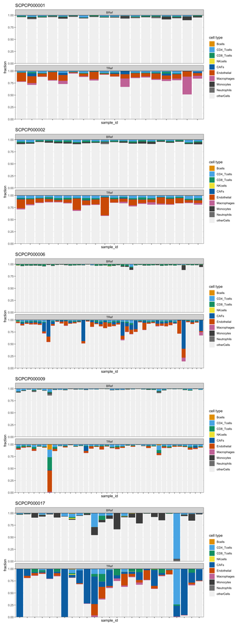

```r
# Next, we'll define a vector of colors to use for plots which ensures that shared cell types have the same colors
# hex codes are (mostly) from Okabe-Ito
color_map <- c(
  # shared cell types
  "Bcells" = "#E69F00",
  "CD4_Tcells" = "#56B4E9",
  "CD8_Tcells" = "#009E73",
  "NKcells" =  "#F0E442",
  # reference-specific cell types
  "CAFs" = "#0072B2",
  "Endothelial" = "#D55E00",
  "Macrophages" = "#CC79A7",
  "Monocytes" = "grey30",
  "Neutrophils" = "grey50",
  "otherCells" = "grey95"
)
celltype_levels <- c(names(color_map))

unique(epic_raw_df$project_id) |>
  purrr::map(
    \(scpca_project_id) {

      epic_proj_df <- epic_raw_df |>
        dplyr::filter(project_id == scpca_project_id)

      ggplot(epic_proj_df) +
      aes(
        x = sample_id,
        y = fraction,
        fill = forcats::fct_relevel(epic_celltype, celltype_levels)
      ) +
      geom_col() +
      facet_wrap(vars(reference), nrow = 2) +
      scale_y_continuous(expand = c(0,0)) +
      scale_fill_manual(values = color_map, name = "cell type") +
      ggtitle(scpca_project_id) +
      theme(axis.text.x = element_blank())
  }
) |>
  patchwork::wrap_plots(nrow = 5)
```

In most samples, the vast majority of cells are `otherCells`, although there are several samples which are estimated to have ~100% cells classified; it is very likely that cells in these samples (and possibly more samples) are incorrectly classified.

We also see these trends:

- For all projects, `BRef` tends to classify fewer cells compared to `TRef`, although it is important to note that a higher classified proportion does *not* necessarily mean that those cells *should* be classified!
- For both references and across all samples, there appear to be very few inferred B-cells and NK-cells. This cell type is indeed present in both references, but it is only rarely observed which is notable.
- There appears to be substantial misclassification of cell types in `SCPCP000017` (osteosarcoma) by `TRef`. Several samples are fully classified and/or dominated by, if not entirely comprised of, cancer-associated fibroblasts. Many of those cells are probably tumor cells which `EPIC` has misclassified, so `TRef` appears to be is a misleading reference for this project.
- We know *a priori* that Wilms Tumor (`SCPCP000006`) samples are expected to have a mix of endothelial cells, stromal, and blastemal cells, and we further expect that stromal cells may have similar characteristics to cancer-associated fibroblasts. Therefore, the `TRef` reference may be misclassifying tumor cells as endothelium and CAFs which are fairly prevalent in the barplots for these samples.
- We see some expected patterns in the brain & CNS tumors:
  - `TRef` observations:
    - Macrophages are most commonly observed in `SCPCP000001` (high-grade glioma) samples
    - Endothelial cells tend to dominate `SCPCP000001` and `SCPCP000002` (low-grade glioma) and are very prevalent in `SCPCP000009` (CNS tumors)
  - `BRef` observations:
    - Leukocytes generally speaking dominate these inferences for all three of these projects, but it’s important to note that monocytes are not present in `TRef`.
- Generally speaking for `BRef` results:
  - CD4 T-cells and monocytes are prevalent in `SCPCP000017`, which is consistent withe expectations for osteosarcoma
  - CD8 T-cells dominate `SCPCP000006` cell types

Based on these observations, we will select the following references for each project:

| Project | High-level diagnosis | `EPIC` Reference |
| --- | --- | --- |
| SCPCP000001 | High-grade glioma | `TRef` |
| SCPCP000002 | Low-grade glioma | `TRef` |
| SCPCP000006 | Wilms tumor | `BRef` |
| SCPCP000009 | CNS tumors | `TRef` |
| SCPCP000017 | Osteosarcoma | `BRef` |

We’ll create a data frame `epic_df` with only results for the given reference/project pairs:

```r
tref_projects <- c("SCPCP000001", "SCPCP000002", "SCPCP000009")
bref_projects <- c("SCPCP000006", "SCPCP000017")

# Filter based on projects and references
epic_tref <- epic_raw_df |>
  dplyr::filter(
    project_id %in% tref_projects,
    reference == "TRef"
  )

epic_bref <- epic_raw_df |>
  dplyr::filter(
    project_id %in% bref_projects,
    reference == "BRef"
  )

# Create final epic_df with only references of interest for each project
epic_df <- dplyr::bind_rows(
  epic_tref,
  epic_bref
) |>
  # add column to support interpreting figure panels with projects, diagnosis, and EPIC reference
  dplyr::mutate(
    project = dplyr::case_match(
      project_id,
      "SCPCP000001" ~ "01: High-grade glioma (TRef)",
      "SCPCP000002" ~ "02: Low-grade glioma (TRef)",
      "SCPCP000006" ~ "06: Wilms tumor (BRef)",
      "SCPCP000009" ~ "09: CNS tumors (TRef)",
      "SCPCP000017" ~ "17: Osteosarcoma (BRef)",
    ),
    # arrange in order of reference, not project
    project = forcats::fct_relevel(project, "09: CNS tumors (TRef)", after = 2)
  ) |>
  dplyr::select(project, sample_id, epic_celltype, fraction)

head(epic_df)
```

| project | sample_id | epic_celltype | fraction |
| --- | --- | --- | --- |
| 01: High-grade glioma (TRef) | SCPCS000001 | Bcells | 0.0008765501 |
| 01: High-grade glioma (TRef) | SCPCS000001 | CAFs | 0.0020606142 |
| 01: High-grade glioma (TRef) | SCPCS000001 | CD4_Tcells | 0.0249805460 |
| 01: High-grade glioma (TRef) | SCPCS000001 | CD8_Tcells | 0.0085382879 |
| 01: High-grade glioma (TRef) | SCPCS000001 | Endothelial | 0.1768336951 |
| 01: High-grade glioma (TRef) | SCPCS000001 | Macrophages | 0.0114720047 |

## Visualization with selected reference

Let’s have a quick look at the proportion of classified cells overall (i.e., 1 - `other`)

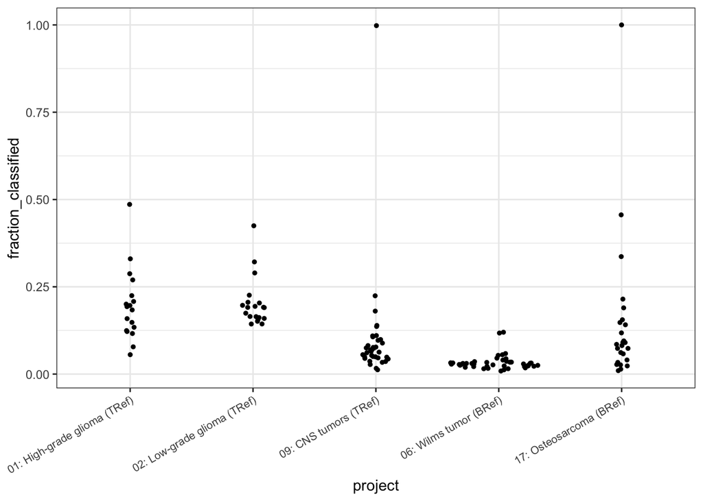

```r
epic_classified_df <- epic_df |>
  dplyr::filter(epic_celltype == "otherCells") |>
  dplyr::mutate(fraction_classified = 1 - fraction)

ggplot(epic_classified_df) +
  aes(x = project, y = fraction_classified) +
  ggforce::geom_sina(size = 1) +
  theme(axis.text.x = element_text(angle = 30, hjust = 1, size = rel(0.9)))
```

In the vast majority of samples, fewer than 25% of cells are classified, with the fewest cells classified in Wilms Tumor.

Notably, across samples, there appear to be very few B-cells or NK cells inferred, and with the exception of only a handful of samples at most, when they are inferred the fractions are extremely small (to the point that we might essentially consider them to be 0).

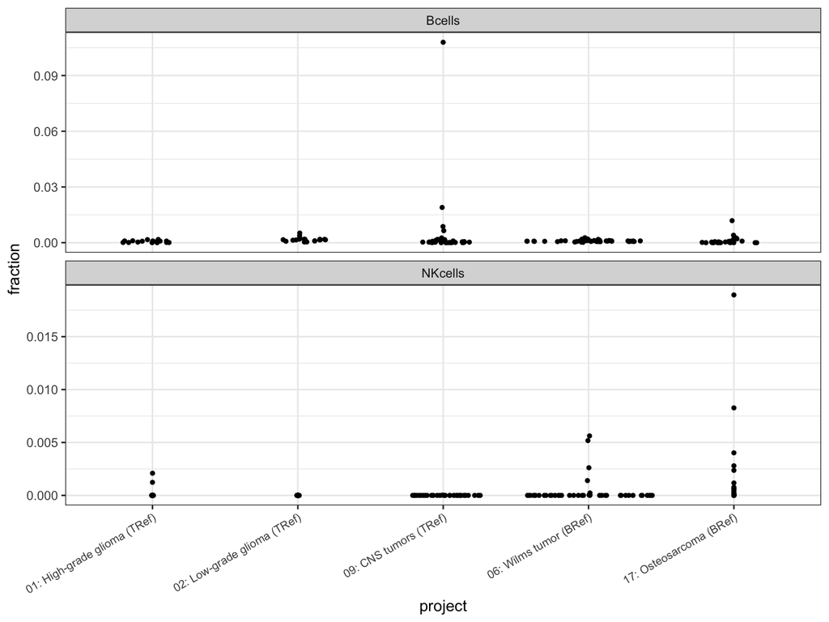

```r
epic_bcell_df <- epic_df |>
  dplyr::filter(epic_celltype %in% c("Bcells", "NKcells"))

ggplot(epic_bcell_df) +
  aes(x = project, y = fraction) +
  ggforce::geom_sina(size = 1) +
  facet_wrap(vars(epic_celltype), nrow = 2, scales = "free_y") +
  theme(axis.text.x = element_text(angle = 30, hjust = 1, size = rel(0.9)))
```

### Number of identified cell types

How many cell types are represented in each sample? For this, we’ll make a histogram of the number of cell types identified per sample (regardless of their proportion). Since, as it seems, EPIC generally doesn’t estimate 0’s, we’ll instead provide a low threshold value of `1e-4` (artbitrarily chosen as low but not *too* low!).

Note that the maximum number of cell types is 7 for `TRef` and 6 for `BRef` (not including other).

```r
celltype_counts_df <- epic_df |>
  dplyr::filter(epic_celltype != "otherCells") |>
  dplyr::group_by(project, sample_id) |>
  dplyr::summarize(num_celltypes = sum(fraction > 1e-4))
```

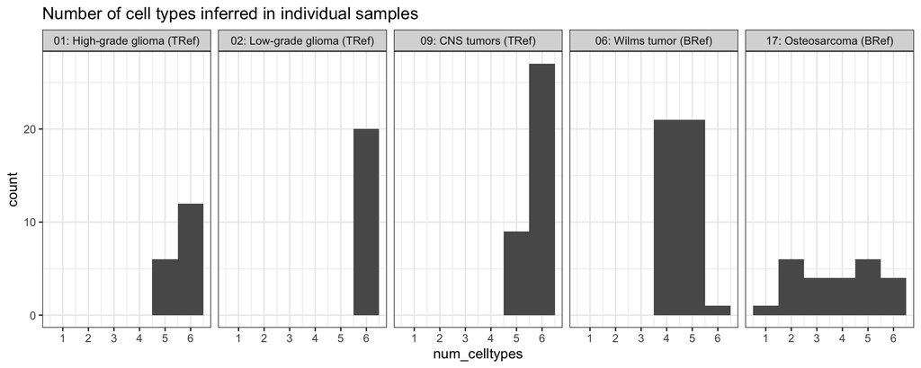

```r
ggplot(celltype_counts_df) +
  aes(x = num_celltypes) +
  geom_histogram(center = 0, binwidth = 1) +
  scale_x_continuous(breaks = scales::breaks_pretty()) +
  facet_wrap(vars(project), nrow = 1) +
  ggtitle("Number of cell types inferred in individual samples")
```

We can also make an associated summary table:

```r
celltype_counts_df |>
  dplyr::group_by(project) |>
  dplyr::summarize(
    min_celltypes = min(num_celltypes),
    median_celltypes = median(num_celltypes),
    max_celltypes = max(num_celltypes),
  )
```

| project | min_celltypes | median_celltypes | max_celltypes |
| --- | --- | --- | --- |
| 01: High-grade glioma (TRef) | 5 | 6 | 6 |
| 02: Low-grade glioma (TRef) | 6 | 6 | 6 |
| 09: CNS tumors (TRef) | 5 | 6 | 6 |
| 06: Wilms tumor (BRef) | 4 | 5 | 6 |
| 17: Osteosarcoma (BRef) | 1 | 4 | 6 |

Let’s look at how many samples contain each cell type: Again, this only considers cell type presence and absence at a `1e-4` threshold.

```r
# calculate number of celltypes per sample
samples_per_celltype_df <- epic_df |>
  dplyr::filter(epic_celltype != "otherCells") |>
  dplyr::group_by(epic_celltype, project) |>
  dplyr::summarize(n_samples = sum(fraction > 1e-4))
# convert number to proportion
samples_per_celltype_df <- epic_df |>
  dplyr::filter(epic_celltype == "otherCells") |>
  dplyr::count(project) |>
  dplyr::right_join(samples_per_celltype_df) |>
  dplyr::mutate(prop_samples = n_samples / n)
```

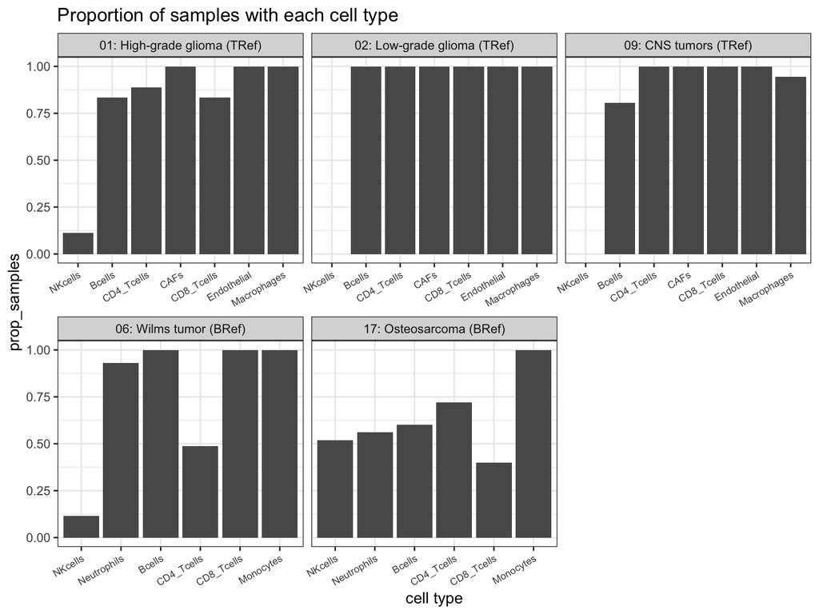

```r
ggplot(samples_per_celltype_df) +
  aes(
    x = forcats::fct_reorder(epic_celltype, prop_samples),
    y = prop_samples) +
  geom_col() +
  facet_wrap(vars(project), nrow = 2, scales = "free_x") +
  theme(axis.text.x = element_text(angle = 30, hjust = 1, size = rel(0.8))) +
  labs(
    x = "cell type",
    title = "Proportion of samples with each cell type"
  )
```

This figure emphasizes the overall rarity of `NKcells`: They are rarely observed in samples from `SCPCP000001` and `SCPCP000006`, and are virtually unobserved in `SCPCP000002` and `SCPCP000009`.

## Conclusions

`EPIC` appears to be a more conservative method and, frequently, cell types present in the reference are not present in the samples even though we might have *a priori* expectations they are present. There are also samples which were virtually entirely classified, but these inferences are not unlikely to be spurious. The next step will be to compare these inferences with `quanTIseq` inferences.